# Data Management / Visualization Assignment

Merritt Ebner

2/26/2022

```r
library('tidyverse')
library("jpeg")
library("patchwork")
p <- read.csv('w02-penguins.csv')
```

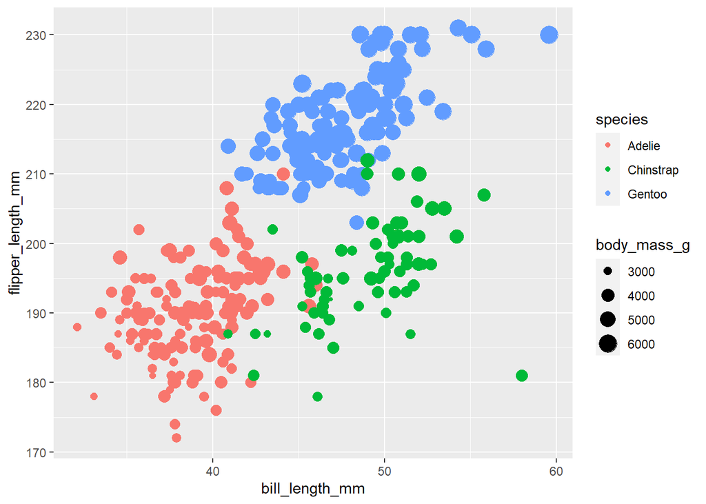

```r
peng_plot <- ggplot(data = p)+
  geom_point(mapping = aes(bill_length_mm, flipper_length_mm,color=species,size=body_mass_g))
peng_plot
```

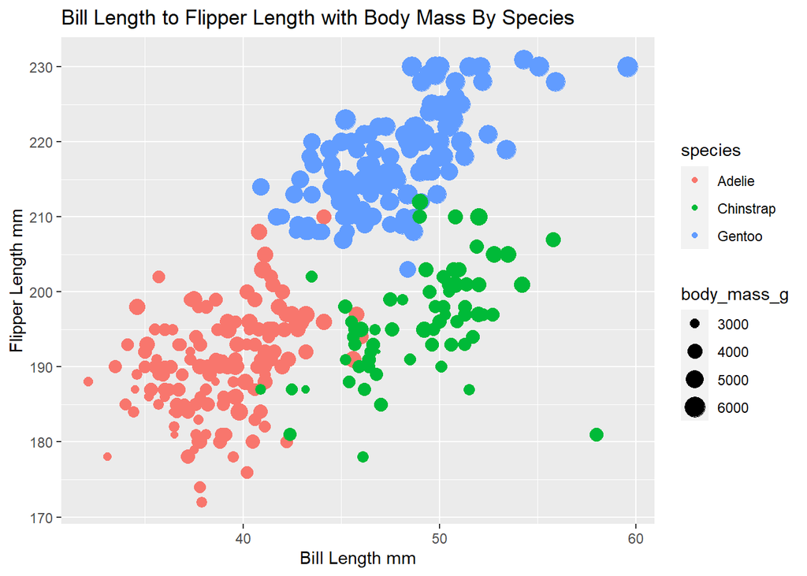

```r
ppl <- peng_plot+labs(x="Bill Length mm",y="Flipper Length mm",
                      title = "Bill Length to Flipper Length with Body Mass By Species")
ppl
```

```r
download.file("https://www.antarctica.gov.au/site/assets/files/45567/rs31765_kings_in_waves_gg_feb_2016_kk.1600x0.jpg",
              "penguin.jpg",
              mode = "wb")

my_image1 <-  readJPEG("penguin.jpg")
raster.peng <- as.raster(my_image1)
```

The Original Graph from the last assignment.

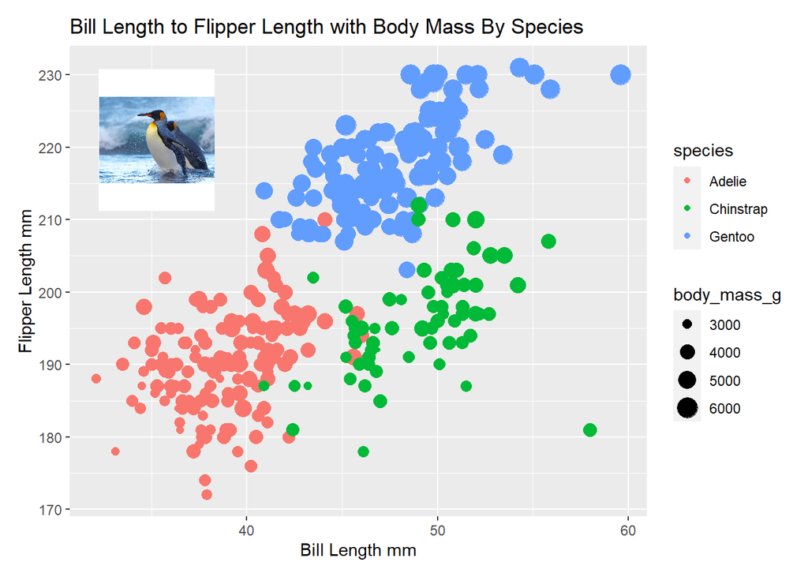

```r
img_graph2 <- ppl +
  inset_element(p = raster.peng,
                left = 0.05,
                bottom = 0.65,
                right = 0.25,
                top = 0.95)
img_graph2
```

Changing the shape made it harder to understand.

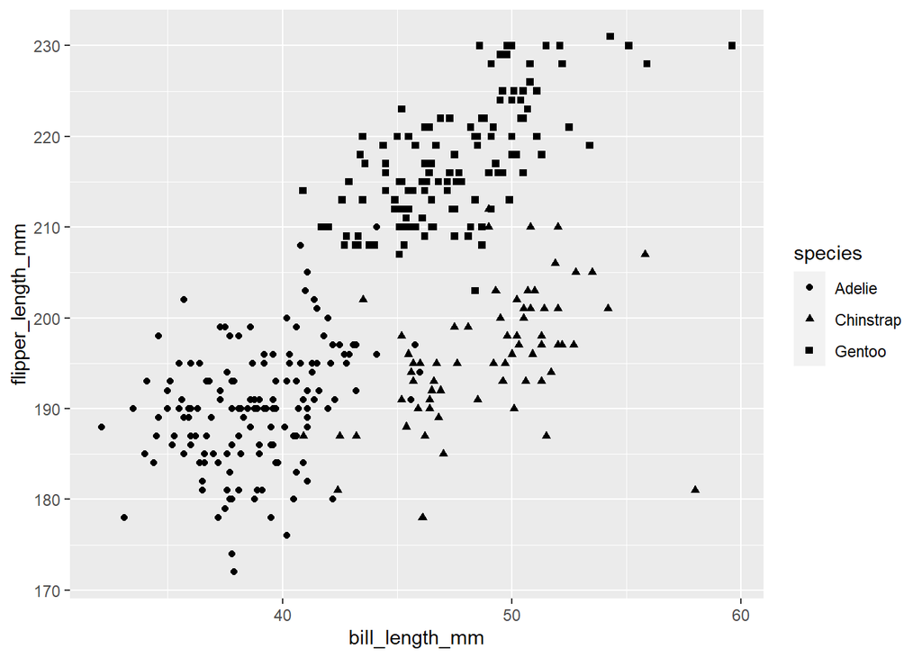

```r
ggplot(data=p)+
  geom_point(mapping= aes(bill_length_mm,flipper_length_mm, shape=species))
```

This is somewhat better than the previous but still not optimal.

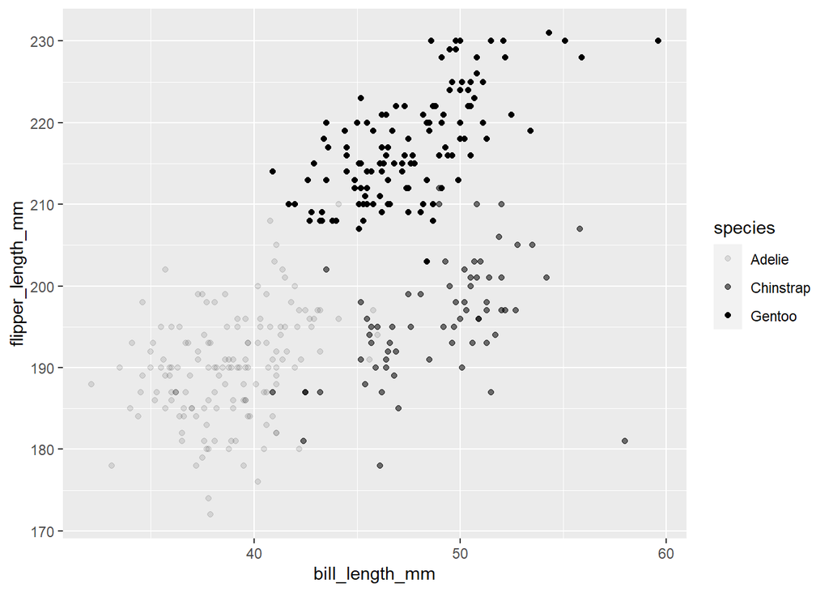

```r
ggplot(data=p)+
  geom_point(mapping= aes(bill_length_mm,flipper_length_mm, alpha=species))
```

Using facet wrap gives a clear picture of the trends of each species without any visual interference from other species.

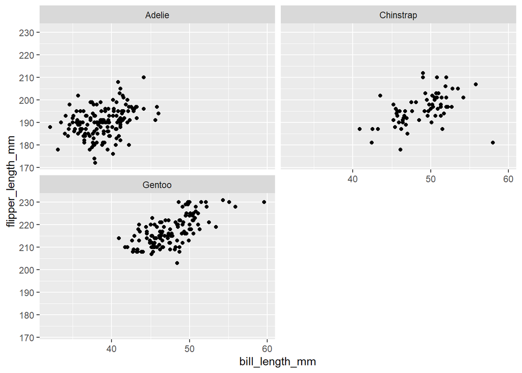

```r
ggplot(data=p)+
  geom_point(mapping= aes(bill_length_mm,flipper_length_mm))+
  facet_wrap(~ species,nrow=2)
```

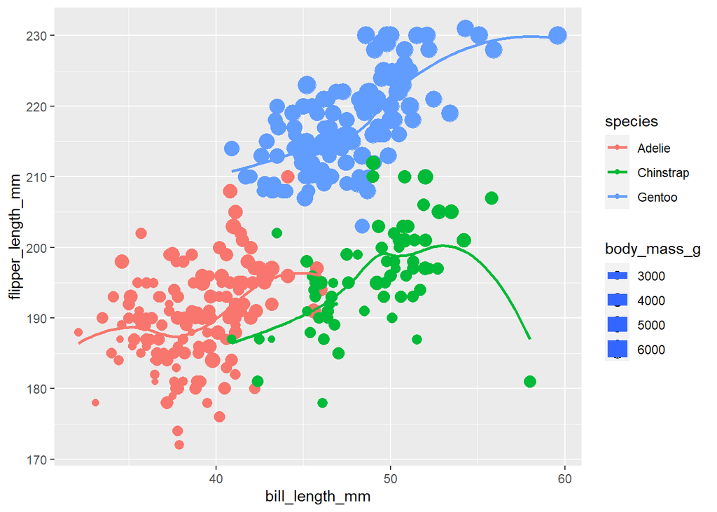

```r
ggplot(data=p,mapping=aes(bill_length_mm,flipper_length_mm,color=species,size=body_mass_g))+
  geom_point(mapping = aes(color=species))+
  geom_smooth(
    data=filter(p,species=='Adelie'),
    se=F
  )+
  geom_smooth(
    data=filter(p,species=='Chinstrap'),
    se=F
  )+
  geom_smooth(
    data=filter(p,species=='Gentoo'),
    se=F
  )
```

```r
# Change histogram plot line colors by groups
scatter01 <- ggplot(p, aes(x = bill_length_mm, y = flipper_length_mm,
                              color = species,
                              size = body_mass_g)) +
  geom_point(alpha = 0.5)
# Overlaid histograms
hist01 <- ggplot(p, aes(x = bill_depth_mm, color=species)) +
          geom_histogram(fill="navy",
                         alpha = 0.3,
                         position = "identity",
                         binwidth = 0.2)
## use plot_grid() in {cowplot} to layout the two plots
#plot_grid(scatter01, hist01, labels=c("A", "B"), ncol = 2, nrow = 1)
```

```r
pplot2 <- scatter01 +labs(x="Bill Length mm",y="Flipper Length mm",
                      title = "Bill Length to Flipper Length")
```

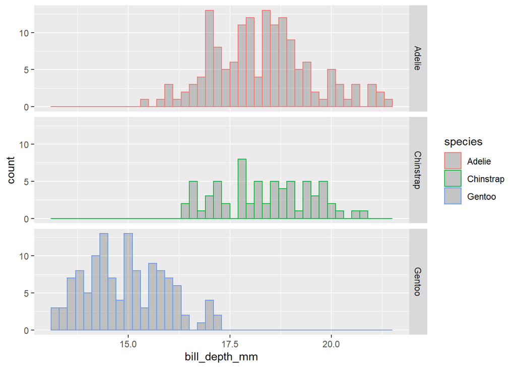

```r
 plot2 <- ggplot(p, aes(x = bill_depth_mm, color=species)) +
          geom_histogram(
                         alpha = 0.3,
                         position = "identity",
                         binwidth = 0.2)+
  facet_grid(species~.)
plot2
```

```r
pplot3 <- plot2 +labs(x="Bill Depth mm",y="Count",
                      title = "Bill Depth by Species.")
```

An interesting finding looking at the two charts side by side is that Gentoo penguins have the highest average flipper length but the lowest average bill depth.

```r
#plot_grid(pplot2, pplot3, labels=c("A", "B"),ncol = 2, nrow = 1)
```

Part 2 of Assignment 2.

Delete all records with at least one missing component.

```r
not_missing <- na.omit(p)
```

```r
fin.data <- not_missing %>%
  filter(species == "Adelie" | species =="Gentoo",
         island =="Biscoe" | island=="Torgersen",
         body_mass_g < 5000 & body_mass_g > 3500) %>%
  mutate(BMI= body_mass_g / 4000) %>%
  select(-X,-sex,-year,-body_mass_g)
```

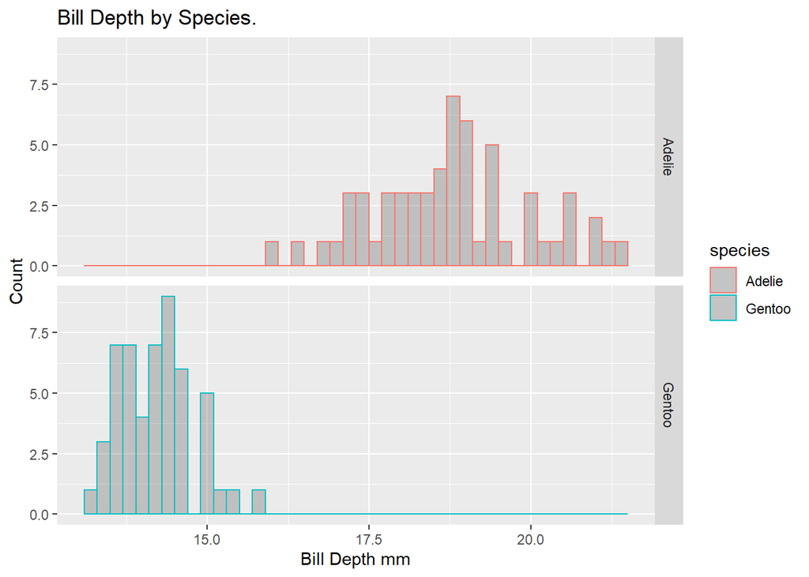

```r
plot4 <- ggplot(fin.data, aes(x = bill_depth_mm, color=species)) +
          geom_histogram(
                         alpha = 0.3,
                         position = "identity",
                         binwidth = 0.2)+
  facet_grid(species~.)
pplot4 <- plot4 +labs(x="Bill Depth mm",y="Count",
                      title = "Bill Depth by Species.")
pplot4
```

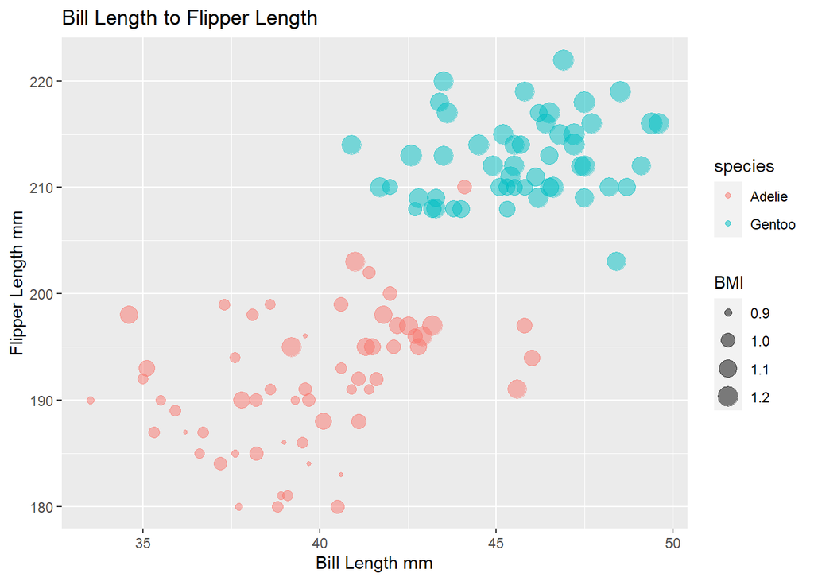

```r
scatter02 <- ggplot(fin.data, aes(x = bill_length_mm, y = flipper_length_mm,
                              color = species,
                              size = BMI)) +
  geom_point(alpha = 0.5)
scatter02 <- scatter02 +labs(x="Bill Length mm",y="Flipper Length mm",
                      title = "Bill Length to Flipper Length")
scatter02
```

```r
#plot_grid(scatter02, pplot4, labels=c("A", "B"),ncol = 2, nrow = 1)
```

It is clear that Adelie penguins have smaller flipper and bill lengths on average compared to Gentoo penguins. Despite this, Adelie penguins have much larger bill depth on average compared to Gentoo penguins. An interesting observation is that Adelie penguins also appear to have much more BMI variation compared to Gentoo penguins. Almost all Gentoo penguins appear to have BMI’s above 1.0 while there are a noticeable amount of Adelie penguins with BMI’s above and below 1.0.